# 大气环境生物气溶胶感染风险评估报告

# 1. 评估概要

本报告依据《大气环境生物气溶胶健康风险评估技术方法指南》（T/CSES XXXX-XXXX）第六章编制。

- **目标病原体**：legionella pneumophila
- **暴露人群**：Adult
- **微环境**：Outdoor，**季节**：Annual
- **模拟方法**： 一维蒙特卡洛（仅传播变异性）
- **评估工具**：`airqmra` R 包（版本 0.0.0.9000）

# 2. 数据来源

- **暴露浓度**：来源于现场采样及实验室分析。
- **剂量‑反应参数**：来自 `airqmra` 内置数据库（`pathogen_db`）。
- **暴露参数**：主要引自《中国人群暴露参数手册》。

# 3. 评估方法

## 3.1 危害识别

legionella pneumophila 为感染性病原体，主要经吸入途径引起感染。

## 3.2 剂量‑反应评估

本次评估选用 **exponential** 模型。
$$P = 1 - \exp(-k \cdot d)$$
参数 **k** = 4.99e-05

## 3.3 暴露评估

$$d = C \times IR \times T \times
f_{\text{survival}} \times f_{\text{deposition}}$$

[output not shown]

```
## **暴露时间 (T)**：根据微环境与季节从时间‑活动数据库加载。
```

```
## **存活率 (f_survival)**：来自实证研究，对数正态分布，μ = -1.322, σ = 0.427。
```

[output not shown]

## 3.4 风险表征

# 4. 评估结果

## 4.1 单次感染风险

```
## **统计摘要**
##      Min.   1st Qu.    Median      Mean   3rd Qu.
## 6.173e-06 1.154e-04 2.304e-04 3.860e-04 4.538e-04
##      Max.
## 1.300e-02
```

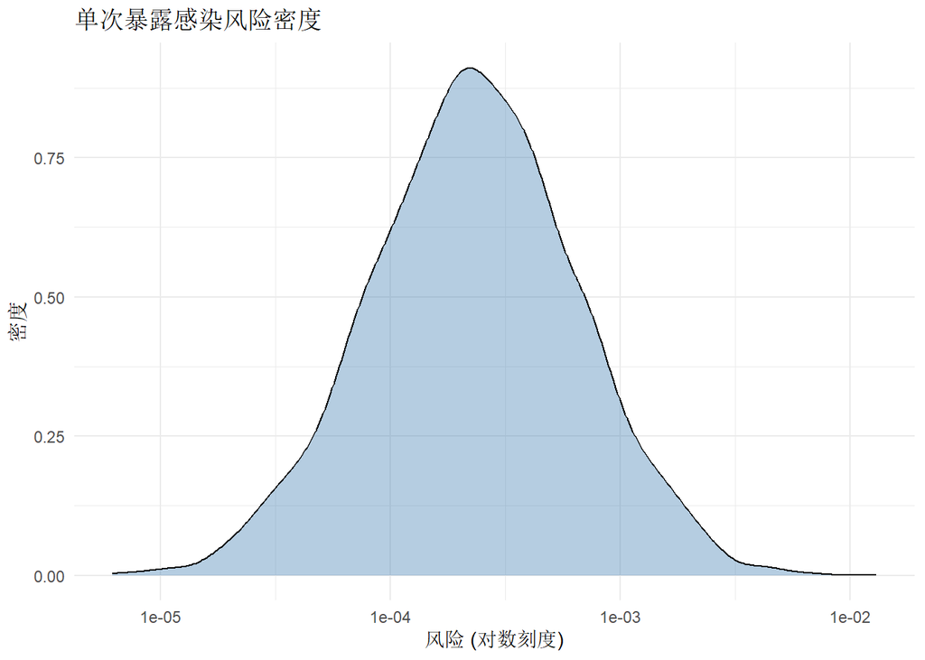